# ProsperLoan_Exploration_Part1

### PROJECT: COMMUNICATE DATA FINDINGS

#### INTRODUCTION

The data set used for this project is the loan data from prosper which contains 113,937 loans with 81 variables on each loan , including loan amount, borrower rate (or interest rate), current loan status, borrower income and many others. This project has two parts that demonstrate the importance and value of data visualizations technique in the data analysis process. This file contains part one which covers exploratory data analysis, part two will cover explanatory data visualization of selected visualizations from part one.

```python
import pandas as pd
import numpy as np
import matplotlib
import matplotlib.pyplot as plt
import seaborn as sns

plt.rcParams.update({'font.family': 'cursive'})
```

```python
# read in the downloaded prosper loan data set.

pd.set_option('max_columns', None) #to display all the columns in the data set

loan_df = pd.read_csv(r'C:\Users\SAMUEL\Documents\Udacity Project\EDA\prosperLoanData.csv')
loan_df.head()
```

|  | ListingKey | ListingNumber | ListingCreationDate | CreditGrade | Term | LoanStatus | ClosedDate | BorrowerAPR | BorrowerRate | LenderYield | EstimatedEffectiveYield | EstimatedLoss | EstimatedReturn | ProsperRating (numeric) | ProsperRating (Alpha) | ProsperScore | ListingCategory (numeric) | BorrowerState | Occupation | EmploymentStatus | EmploymentStatusDuration | IsBorrowerHomeowner | CurrentlyInGroup | GroupKey | DateCreditPulled | CreditScoreRangeLower | CreditScoreRangeUpper | FirstRecordedCreditLine | CurrentCreditLines | … |
| --- | --- | --- | --- | --- | --- | --- | --- | --- | --- | --- | --- | --- | --- | --- | --- | --- | --- | --- | --- | --- | --- | --- | --- | --- | --- | --- | --- | --- | --- | --- |
| 0 | 1021339766868145413AB3B | 193129 | 2007-08-26 19:09:29.263000000 | C | 36 | Completed | 2009-08-14 00:00:00 | 0.16516 | 0.1580 | 0.1380 | NaN | NaN | NaN | NaN | NaN | NaN | 0 | CO | Other | Self-employed | 2.0 | True | True | NaN | 2007-08-26 18:41:46.780000000 | 640.0 | 659.0 | 2001-10-11 00:00:00 | 5.0 | … |
| 1 | 10273602499503308B223C1 | 1209647 | 2014-02-27 08:28:07.900000000 | NaN | 36 | Current | NaN | 0.12016 | 0.0920 | 0.0820 | 0.07960 | 0.0249 | 0.05470 | 6.0 | A | 7.0 | 2 | CO | Professional | Employed | 44.0 | False | False | NaN | 2014-02-27 08:28:14 | 680.0 | 699.0 | 1996-03-18 00:00:00 | 14.0 | … |
| 2 | 0EE9337825851032864889A | 81716 | 2007-01-05 15:00:47.090000000 | HR | 36 | Completed | 2009-12-17 00:00:00 | 0.28269 | 0.2750 | 0.2400 | NaN | NaN | NaN | NaN | NaN | NaN | 0 | GA | Other | Not available | NaN | False | True | 783C3371218786870A73D20 | 2007-01-02 14:09:10.060000000 | 480.0 | 499.0 | 2002-07-27 00:00:00 | NaN | … |
| 3 | 0EF5356002482715299901A | 658116 | 2012-10-22 11:02:35.010000000 | NaN | 36 | Current | NaN | 0.12528 | 0.0974 | 0.0874 | 0.08490 | 0.0249 | 0.06000 | 6.0 | A | 9.0 | 16 | GA | Skilled Labor | Employed | 113.0 | True | False | NaN | 2012-10-22 11:02:32 | 800.0 | 819.0 | 1983-02-28 00:00:00 | 5.0 | … |
| 4 | 0F023589499656230C5E3E2 | 909464 | 2013-09-14 18:38:39.097000000 | NaN | 36 | Current | NaN | 0.24614 | 0.2085 | 0.1985 | 0.18316 | 0.0925 | 0.09066 | 3.0 | D | 4.0 | 2 | MN | Executive | Employed | 44.0 | True | False | NaN | 2013-09-14 18:38:44 | 680.0 | 699.0 | 2004-02-20 00:00:00 | 19.0 | … |

###### defining some notable variables

- Listing key: A unique key for each listing, same value as the 'key' used in the listing object in the API.
- ListingCreationDate: The date the listing was created.
- CreditGrade: The credit rating that was assigned at the time the listing went live. Applicable for listings pre-2009 period and is only populated for those listings.
- LoanStatus: The current status of the loan: Cancelled, Chargedoff, Completed, Current, Defaulted, FinalPaymentInProgress, Paastdue. The pastdue status is accompanied by a deliquency bucket.
- BorrowerAPR: The borrower's Annual Percentage Rate (APR) for the loan.
- BorrowerRate: The borrower's interest rate for this loan.
- ProsperRating (numeric): The prosper rating assigned at the time the listig was created. 0-N/A, 1-HR, 2-E, 3-D, 4-C, 5-B, 6-A, 7-AA. Applicable for loans originated after July 2009.
- ProsperRating (Alpha): The prosper rating assigned at the time the listing was created between AA-HR. Applicable for loans originated after July 2009.
- ProsperScore: A custom risk score built using historical Prosper data. The score ranges from 1-10, with 10 being the best or lowest risk score. Applicable for loans originated after July 2009.
- ListingCategory: The category of the listing that the borrower selected when posting their listing. 0- "Not Available", 1- "Debt Consolidation", 2- "Home Improvement", 3- "Business", 4- "Personal Loans", 5- "Student Use", 6- "Auto", 7- "Other", 8- "Baby & Adoption", 9- "Boat", 10- "Cosmetic Procedure", 11- "Engagement Ring", 12- "Green Loans", 13- "Household expenses", 14- "Large Purchases", 15- "Medical/Dental", 16- "Motorcycle", 17- "RV", 18- "Taxes", 19- "Vacation", 20- "Wedding Loans".
- BorrowerState: The two letter abbreviation of the state of the address of the borrower at the time the listing was created.
- Occupation: The occupation selected by the borrower at the time they created this listing.
- EmploymentStatus: The employment status of the borrower at the time they created this listing.
- IsBorrowerHomeOwner: A borrower is considered home owner if they have a mortgage on their credit profile or provide documentation confirming they are a home owner.
- DebtToIncomeRatio: The debt to income ratio of the borrower at the time the credit profile was pulled. This value is null if the debt to income ratio value is not available. This value is capped at 10.01 (any debt to income ratio larger than 1000% is returned as 1001%)
- IncomeRange: The income range of the borrower at the time the listing was created.
- StatedMonthlyIncome: The monthly income the borrower stated at the time the listing was created.

```python
# getting information on each variables

loan_df.info()
```

```
<class 'pandas.core.frame.DataFrame'>
RangeIndex: 113937 entries, 0 to 113936
Data columns (total 81 columns):
 #   Column                               Non-Null Count   Dtype
---  ------                               --------------   -----
 0   ListingKey                           113937 non-null  object
 1   ListingNumber                        113937 non-null  int64
 2   ListingCreationDate                  113937 non-null  object
 3   CreditGrade                          28953 non-null   object
 4   Term                                 113937 non-null  int64
 5   LoanStatus                           113937 non-null  object
 6   ClosedDate                           55089 non-null   object
 7   BorrowerAPR                          113912 non-null  float64
 8   BorrowerRate                         113937 non-null  float64
 9   LenderYield                          113937 non-null  float64
```

[output cut: 73 more lines]

*Columns like CreditGrade, ProsperRating (numeric), ProsperRating (Alpha), and ProsperScore have many missing values because they are not populated for all the years. CreditGrade is populated for pre-2009, and ProsperScore (Alpha) is populated for 2009 and after. So, it is better to merge the two columns to have a Grade populated for all the listings.*

*Columns like ListingCreationDate, ClosedDate, DateCreditPulled, FirstRecordedCreditLine, LoanOriginationAmount have their data type as objects instead of datetime*

```python
# checking for the number of unique values in all the columns

loan_df.nunique()
```

```
ListingKey                     113066
ListingNumber                  113066
ListingCreationDate            113064
CreditGrade                         8
Term                                3
                                ...
PercentFunded                     719
Recommendations                    17
InvestmentFromFriendsCount         14
InvestmentFromFriendsAmount       726
Investors                         751
Length: 81, dtype: int64
```

*Out of a total of 113,937 loans, there are 113066 unique values in ListingKey column. ListingKey is supposed to be unique for all loans, which means there is a total of 871 duplicated ListingKey which we'll have to drop.*

```python
# getting the descriptive statistics of selected columns

loan_df[['BorrowerAPR', 'BorrowerRate', 'ProsperScore', 'StatedMonthlyIncome']].describe()
```

|  | BorrowerAPR | BorrowerRate | ProsperScore | StatedMonthlyIncome |
| --- | --- | --- | --- | --- |
| count | 113912.000000 | 113937.000000 | 84853.000000 | 1.139370e+05 |
| mean | 0.218828 | 0.192764 | 5.950067 | 5.608026e+03 |
| std | 0.080364 | 0.074818 | 2.376501 | 7.478497e+03 |
| min | 0.006530 | 0.000000 | 1.000000 | 0.000000e+00 |
| 25% | 0.156290 | 0.134000 | 4.000000 | 3.200333e+03 |
| 50% | 0.209760 | 0.184000 | 6.000000 | 4.666667e+03 |
| 75% | 0.283810 | 0.250000 | 8.000000 | 6.825000e+03 |
| max | 0.512290 | 0.497500 | 11.000000 | 1.750003e+06 |

*BorrowerAPR, BorrowerRate, and ProsperScore are normally distributed, since their means are approximately equal to their medians. StatedMonthlyIncome is not normally distributed, it is affected by the presence of outliers. There is a huge difference between the 3rd quartile (6824.688) and the maximum value (1750003).*

```python
# Structure of the dataset before preliminary wranglinng

loan_df.shape
```

```
(113937, 81)
```

#### PRELIMINARY WRANGLING

```python
# replacing numerical values in the ListingCategory column with their corresponding name

loan_df['ListingCategory (numeric)'] = loan_df['ListingCategory (numeric)'].replace({0: "Not Available", 1: "Debt Consolidation", 2: "Home Improvement", 3: "Business", 4: "Personal Loans", 5: "Student Use", 6: "Auto", 7: "Other", 8: "Baby & Adoption", 9: "Boat", 10: "Cosmetic Procedure", 11: "Engagement Ring", 12: "Green Loans", 13: "Household expenses", 14: "Large Purchases", 15: "Medical/Dental", 16: "Motorcycle", 17: "RV", 18: "Taxes", 19: "Vacation", 20: "Wedding Loans"})
```

```python
# Check
loan_df[['ListingCategory (numeric)']].head()
```

|  | ListingCategory (numeric) |
| --- | --- |
| 0 | Not Available |
| 1 | Home Improvement |
| 2 | Not Available |
| 3 | Motorcycle |
| 4 | Home Improvement |

```python
# renaming ProsperRating (numeric), ProsperRating (Alpha), and ListingCategory (numeric) to avoid white spaces

loan_df.rename(columns={'ProsperRating (numeric)':'ProsperRating_Numeric', 'ProsperRating (Alpha)':'ProsperRating_Alpha', 'ListingCategory (numeric)':'ListingCategory'}, inplace=True)
```

```python
# Check

loan_df[['ProsperRating_Numeric', 'ProsperRating_Alpha', 'ListingCategory']].head()
```

|  | ProsperRating_Numeric | ProsperRating_Alpha | ListingCategory |
| --- | --- | --- | --- |
| 0 | NaN | NaN | Not Available |
| 1 | 6.0 | A | Home Improvement |
| 2 | NaN | NaN | Not Available |
| 3 | 6.0 | A | Motorcycle |
| 4 | 3.0 | D | Home Improvement |

```python
# Merging CreditGrade with ProsperRating_Alpha to create a new column Credit_Grade
# Replacing values in the newly created column to create another column, Credit_Grade_Numeric

loan_df['Credit_Grade'] = loan_df['CreditGrade'].fillna('') + loan_df['ProsperRating_Alpha'].fillna('')
loan_df['Credit_Grade_Numeric'] = loan_df['Credit_Grade'].replace({"HR":1, "E":2, "D":3, "C":4, "B":5, "A":6, "AA":7, "":0, "NC":0})
loan_df['Credit_Grade'].replace({"": np.nan}, inplace = True)
loan_df[['Credit_Grade', 'Credit_Grade_Numeric']].head()
```

|  | Credit_Grade | Credit_Grade_Numeric |
| --- | --- | --- |
| 0 | C | 4 |
| 1 | A | 6 |
| 2 | HR | 1 |
| 3 | A | 6 |
| 4 | D | 3 |

```python
# list of duplicated listing keys

loan_df[['ListingKey']].query('ListingKey.duplicated()==True', engine='python')
```

|  | ListingKey |
| --- | --- |
| 9 | 0F043596202561788EA13D5 |
| 999 | 0A0635972629771021E38F3 |
| 2539 | 2D2635984503681189056B4 |
| 4942 | 4B7E3590031274113F1FD34 |
| 5812 | 94B035909835592957503E6 |
| ... | ... |
| 113548 | FB6A35999320129979DBBA3 |
| 113636 | D9BF3589576999233477E75 |
| 113733 | E2303594522341016B8EE15 |
| 113773 | DE8535960513435199406CE |
| 113863 | C74335893905744205D4056 |

871 rows × 1 columns

```python
# dropping the duplicates

duplicates = loan_df[['ListingKey']].query('ListingKey.duplicated()==True', engine='python').index
loan_df.drop(duplicates, axis = 0, inplace = True)
```

```python
# Check

loan_df[['ListingKey']].duplicated().sum()
```

```
0
```

```python
# dropping the top 1% values in the StatedMonthlyIncome column to reduce the effect of outliers

outliers_1 = loan_df['StatedMonthlyIncome'].sort_values(ascending=False).head(int(0.01*loan_df.shape[0])).index
loan_df.drop(outliers_1, axis=0, inplace=True)
```

```python
# Check

loan_df['StatedMonthlyIncome'].describe()
```

```
count    111936.000000
mean       5317.691415
std        3143.788452
min           0.000000
25%        3166.666667
50%        4583.333333
75%        6666.666667
max       20500.000000
Name: StatedMonthlyIncome, dtype: float64
```

```python
# converting the data type of specific columns to datetime

loan_df['ListingCreationDate'] = pd.to_datetime(loan_df['ListingCreationDate'])
loan_df['ClosedDate'] = pd.to_datetime(loan_df['ClosedDate'])
loan_df['DateCreditPulled'] = pd.to_datetime(loan_df['DateCreditPulled'])
loan_df['FirstRecordedCreditLine'] = pd.to_datetime(loan_df['FirstRecordedCreditLine'])
loan_df['LoanOriginationDate'] = pd.to_datetime(loan_df['LoanOriginationDate'])
```

```python
# Check

loan_df[['ListingCreationDate', 'ClosedDate', 'DateCreditPulled', 'FirstRecordedCreditLine', 'LoanOriginationDate']].info()
```

```
<class 'pandas.core.frame.DataFrame'>
Int64Index: 111936 entries, 0 to 113936
Data columns (total 5 columns):
 #   Column                   Non-Null Count   Dtype
---  ------                   --------------   -----
 0   ListingCreationDate      111936 non-null  datetime64[ns]
 1   ClosedDate               54625 non-null   datetime64[ns]
 2   DateCreditPulled         111936 non-null  datetime64[ns]
 3   FirstRecordedCreditLine  111254 non-null  datetime64[ns]
 4   LoanOriginationDate      111936 non-null  datetime64[ns]
dtypes: datetime64[ns](5)
memory usage: 5.1 MB
```

```python
# Structure of the dataset after preliminary wrangling

loan_df.shape
```

```
(111936, 83)
```

- Two more variables have been added and 2001 observations have been dropped

### UNIVARIATE VISUALIZATIONS

#### QUESTION

What is the number of listings that fall under each loan status?

#### VISUALIZATION

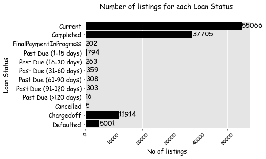

```python
stat = loan_df['LoanStatus'].value_counts()
df = pd.DataFrame({'Status':stat.index, 'Counts':stat.values})

# sort Status values from completed to defaulted listings
df = df.loc[[0, 1, 9, 4, 8, 5, 6, 7, 10, 11, 2, 3]]

plt.style.use('ggplot')
fig, ax = plt.subplots()
plot = sns.barplot(x='Counts', y='Status', data=df, color='k')
plt.bar_label(plot.containers[0], color='k', size=14)
plt.xlabel('No of listings', fontsize=13, color='k')
plt.ylabel('Loan Status', fontsize=13,  color='k')
plt.title('Number of listings for each Loan Status \n', color='k')
plt.xticks(rotation=45, color='k')
plt.yticks(fontsize=12.5, color='k')
plt.show()
```

#### OBSERVATIONS

- Current and Completed listings are the most common, constitutes over 70% of total listings
- less than 30% of prosper loans are either defaulted or charged off

#### QUESTION

What are the proportions of the credit grades of borrowers?

#### VISUALIZATION

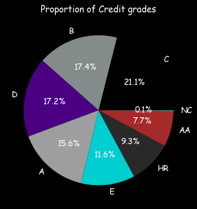

```python
plt.style.use('dark_background')
plt.figure(figsize=(9,5))
col = ['black', '#838B8B', '#4B0082', '#9E9E9E', '#00CED1', '#292929', '#A52A2A', '#7AC5CD']
grade = loan_df['Credit_Grade'].value_counts()
plt.pie(grade, labels = grade.index, colors=col, autopct = '%1.1f%%', textprops={'fontsize':12, 'color':"w"})
plt.title('Proportion of Credit grades', fontsize=13)
plt.show()
```

#### OBSERVATIONS

- The most common credit grade is C. It has the highest proportion of 21%.
- The least common credit grade is NC which means No credit. It has the lowest proportion of 0.1%

#### QUESTION

What are the counts of loans that falls under each income range?

#### VISUALIZATION

```python
dfs = loan_df['IncomeRange'].value_counts()
j = pd.DataFrame({'Income':dfs.index, 'Counts':dfs.values})
j
```

|  | Income | Counts |
| --- | --- | --- |
| 0 | $25,000-49,999 | 31940 |
| 1 | $50,000-74,999 | 30748 |
| 2 | $75,000-99,999 | 16779 |
| 3 | $100,000+ | 16135 |
| 4 | Not displayed | 7667 |
| 5 | $1-24,999 | 7241 |
| 6 | Not employed | 805 |
| 7 | $0 | 621 |

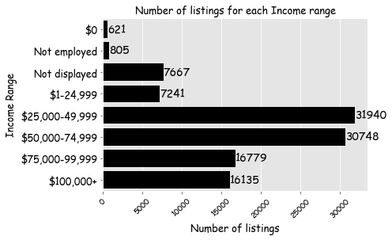

```python
dfs = loan_df['IncomeRange'].value_counts()
j = pd.DataFrame({'Income':dfs.index, 'Counts':dfs.values})

# sort values of Income range from the lowest to the highest
j = j.loc[[7, 6, 4, 5, 0, 1, 2, 3]]

plt.style.use('ggplot')
fig, ax = plt.subplots()
IR = sns.barplot(x='Counts', y='Income', data=j, color='black')
plt.bar_label(IR.containers[0], color='k', size=14)
plt.xticks(rotation=45, color='k')
plt.yticks(fontsize=12.5, color='k')
plt.xlabel('Number of listings', color='k', fontsize=13)
plt.ylabel('Income Range', color='k', fontsize=12.5)
plt.title('Number of listings for each Income range', color='k', fontsize=13)
plt.show()
```

#### OBSERVATIONS

- Most listings fall under income range 25,000-74,999 dollars.
- Few listings fall below 1 dollar, with 'Not employed' considered to be in $0 range

#### QUESTION

How many listings were created for each year?

#### VISUALIZATION

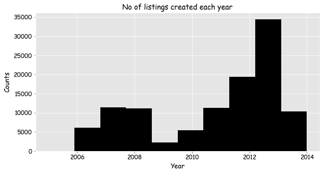

```python
loan_df['ListingCreationDate'].dt.year.hist(figsize=[10,5], color='black')
plt.xlabel('Year', color='k', fontsize=13)
plt.ylabel('Counts', color='k', fontsize=13)
plt.xticks(color='k', fontsize=12)
plt.yticks(color='k', fontsize=12)
plt.title('No of listings created each year', color='k')
plt.show()
```

#### QUESTION

How many listings fall unnder eacch employment status?

#### VISUALIZATION

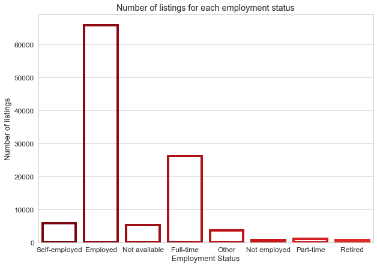

```python
sns.set_style('whitegrid')
plt.figure(figsize=(10,7))
sns.countplot(data=loan_df, x='EmploymentStatus', facecolor=(0,0,0,0),
              linewidth=4, edgecolor=sns.color_palette('Reds_r',24))
plt.xticks(fontsize=12)
plt.yticks(fontsize=12)
plt.xlabel('Employment Status', fontsize=13)
plt.ylabel('Number of listings', fontsize=13)
plt.title('Number of listings for each employment status')
plt.show()
```

#### OBSERVATIONS

- Most listings fall under statuses of people who have a job
- A rare number of listings are for people without a job status

#### QUESTION

Under each employment status, what is the count of borrowers that are home owners or not?

#### VISUALIZATION

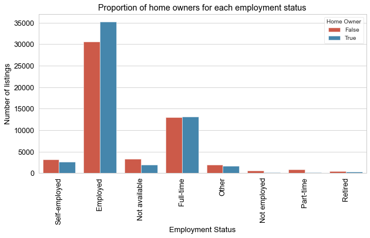

```python
plt.figure(figsize=(10,5))
sns.countplot(data = loan_df, x = 'EmploymentStatus', hue = 'IsBorrowerHomeowner')
plt.legend(title = 'Home Owner')
plt.xticks(rotation=90, fontsize=12.5, color='k')
plt.yticks(fontsize=12.5, color='k')
plt.xlabel('Employment Status', fontsize=13, color='k')
plt.ylabel('Number of listings', fontsize=13, color='k')
plt.title('Proportion of home owners for each employment status', color='k')
plt.show()
```

#### OBSERVATIONS

- There is a close number of home owners and non home owners under each employment status
- Only borrowers under employed or full-time category have a higher count of home owners

#### QUESTION

What are the top 10 occupation of borrowers?

#### VISUALIZATION

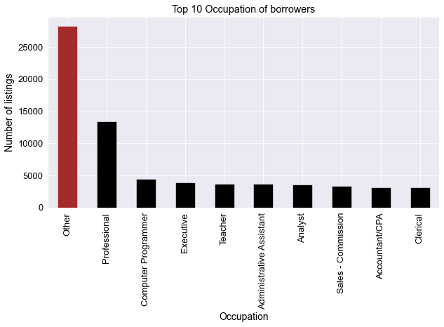

```python
sns.set_style('darkgrid')
plt.figure(figsize=(10,5))
reviz = loan_df.groupby(['Occupation']).count()['ListingKey'].sort_values(ascending=False).head(10)
cols = ['black']*10
cols[0] = '#A52A2A'
reviz.plot(kind = 'bar', color=cols)
plt.xticks(fontsize=13, color='k')
plt.yticks(fontsize=13, color='k')
plt.xlabel('Occupation', fontsize=14, color='k')
plt.ylabel('Number of listings', fontsize=14, color='k')
plt.title('Top 10 Occupation of borrowers', color='k')
plt.show()
```

#### OBSERAVTIONS

- Most borrowers fall under 'Other' category of Occupations
- Aside 'Others', the top occupations of borrowers are Professional, Computer Programmer, Executive, and Teacher

#### QUESTION

What are the top 10 states of borrowers?

#### VISUALIZATION

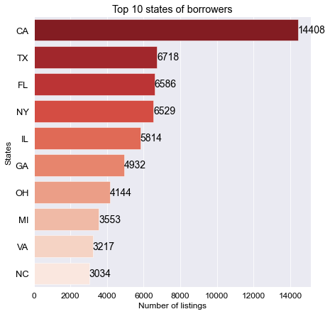

```python
plt.figure(figsize=(7,7))
i = loan_df['BorrowerState'].value_counts().head(10)
j = pd.DataFrame({'States':i.index, 'Counts':i.values})
top10 = sns.barplot(x='Counts', y='States', data=j, palette='Reds_r')
plt.bar_label(top10.containers[0], color='k', size=14)
plt.xticks(fontsize=12, color='k')
plt.yticks(fontsize=13, color='k')
plt.title('Top 10 states of borrowers', color='k')
plt.xlabel('Number of listings', color='k')
plt.ylabel('States', color='k')
plt.show()
```

#### QUESTION

How many listings fall under each listing category?

#### VISUALIZATION

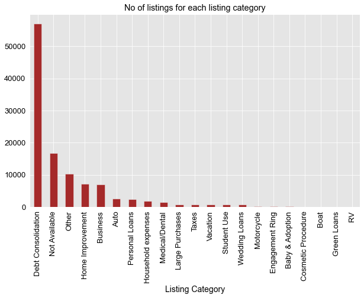

```python
plt.figure(figsize=(10,6))
al = loan_df['ListingCategory'].value_counts()
al.plot(kind = 'bar', color = '#A52A2A')
plt.xticks(rotation = 90, fontsize=13, color='k')
plt.yticks(fontsize=13, color='k')
plt.xlabel('Listing Category', fontsize=14, color='k')
plt.title('No of listings for each listing category', color='k')
plt.show()
```

#### OBSERVATIONS

- Debt Consolidation is the most common listing category. It constitutes of about 50% of the total listings

#### QUESTION

What is the proportion of borrowers that are home owners or not?

#### VISUALIZATION

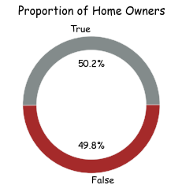

```python
color_ = ['#838B8B', '#A52A2A']
pi = loan_df['IsBorrowerHomeowner'].value_counts()
plt.pie(pi, colors=color_, labels = pi.index, autopct = '%1.1f%%', textprops={'fontsize':12, 'color':'k'})
centre = plt.Circle((0, 0), 0.80, fc='w')
fig = plt.gcf()
fig.gca().add_artist(centre)
plt.title('Proportion of Home Owners', color='k')
plt.show()
```

#### OBSERVATIONS

- The proportion of home owners and non home owners are approximately equal

### BIVARIATE VISUALIZATIONS

#### QUESTION

What is the sum of stated monthly income for each employment status?

#### VISUALIZATION

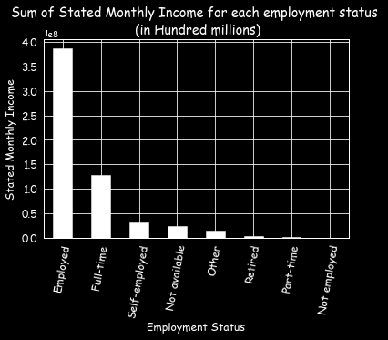

```python
plt.style.use('dark_background')

loa = loan_df.groupby(['EmploymentStatus']).sum()['StatedMonthlyIncome'].sort_values(ascending=False)
loa.plot(kind = 'bar', color = 'w')
plt.ylabel('Stated Monthly Income', fontsize=12)
plt.xlabel('Employment Status', fontsize=12)
plt.xticks(rotation=80, fontsize=12)
plt.yticks(fontsize=12)
plt.title('Sum of Stated Monthly Income for each employment status \n (in Hundred millions)')
plt.show()
```

#### OBSERVATIONS

- Employed borrowers have the highest sum of stated monthly income, of almost 400 million dollars.

#### QUESTION

How does credit grade affect loan status?

#### VISUALIZATION

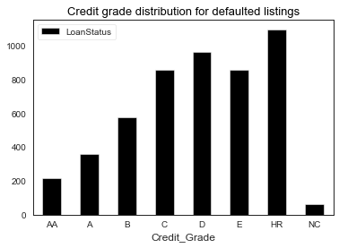

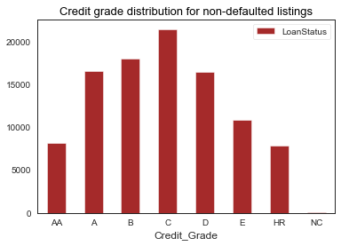

```python
plt.style.use('ggplot')
sns.set_style('white')
plt.figure(figsize=(9,4))

s = loan_df[['LoanStatus', 'Credit_Grade']].query('LoanStatus=="Defaulted"' or
    'LoanStatus=="Chargedoff"').groupby(['Credit_Grade']).count().loc[['AA', 'A', 'B', 'C', 'D', 'E', 'HR', 'NC']]

s.plot(kind='bar', color='black')
plt.title('Credit grade distribution for defaulted listings', color='k', fontsize=13)
plt.xticks(rotation=0)

t = loan_df[['LoanStatus', 'Credit_Grade']].query('LoanStatus!="Defaulted"' and
    'LoanStatus!="Chargedoff"').groupby(['Credit_Grade']).count().loc[['AA', 'A', 'B', 'C', 'D', 'E', 'HR', 'NC']]
t.plot(kind='bar', color='#A52A2A')
plt.title('Credit grade distribution for non-defaulted listings', color='k', fontsize=13)
plt.xticks(rotation=0)

plt.show()
```

#### OBSERVATIONS

- For defaulted listings, most listings have a bad credit grade (from D to HR)
- For non defaulted listings, most listings have a good credit grade (from A to D)
- The lower the credit grade, the more likely for borrowers to default

#### QUESTION

How does listing category affect loan status?

#### VISUALIZATION

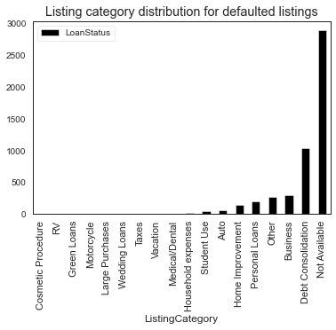

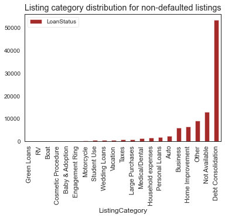

```python
# How listing grade affects loan status

plt.figure(figsize=(9,4))

s = loan_df[['LoanStatus', 'ListingCategory']].query('LoanStatus=="Defaulted"' or
                                                    'LoanStatus=="Chargedoff"').groupby(['ListingCategory']).count().sort_values(by='LoanStatus')
s.plot(kind='bar', color='black')
plt.title('Listing category distribution for defaulted listings')
plt.xticks(rotation=90, fontsize=11)

t = loan_df[['LoanStatus', 'ListingCategory']].query('LoanStatus!="Defaulted"' and
                                                    'LoanStatus!="Chargedoff"').groupby(['ListingCategory']).count().sort_values(by='LoanStatus')
t.plot(kind='bar', color='#A52A2A')
plt.title('Listing category distribution for non-defaulted listings')
plt.xticks(rotation=90, fontsize=11)

plt.show()
```

#### OBSERVATIONS

- For defaulted listings, the most common listing category is 'Not Available'
- For Non defaulted listings, the most common listing category is 'Debt Consolidation'
- A borrower is more likely to default if their listing category falls under 'Not Available'.

#### QUESTION

How does employment status affect loan status?

#### VISUALIZATION

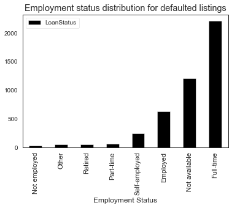

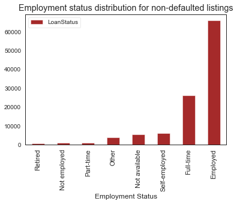

```python
plt.figure(figsize=(9,4))

s = loan_df[['LoanStatus', 'EmploymentStatus']].query('LoanStatus=="Defaulted"' or
                                                     'LoanStatus=="Chargedoff"').groupby(['EmploymentStatus']).count().sort_values(by='LoanStatus')
s.plot(kind='bar', color='black')
plt.title('Employment status distribution for defaulted listings')
plt.xlabel('Employment Status')
plt.xticks(rotation=90, fontsize=11)

t = loan_df[['LoanStatus', 'EmploymentStatus']].query('LoanStatus!="Defaulted"' and
                                                     'LoanStatus!="chargedoff"').groupby(['EmploymentStatus']).count().sort_values(by='LoanStatus')
t.plot(kind='bar', color='#A52A2A')
plt.title('Employment status distribution for non-defaulted listings')
plt.xlabel('Employment Status')
plt.xticks(rotation=90, fontsize=11)

plt.show()
```

#### OBSERVATIONS

- Listings that fall under 'Employed' are not likely to default
- Listings that fall under 'Not Available' are more likely to default

#### QUESTION

What are the top 10 occupations with the highest sum of original loan amount?

#### VISUALIZATION

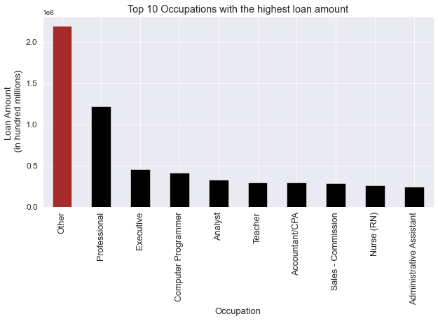

```python
sns.set_style('darkgrid')
plt.figure(figsize=(10,5))
tops = loan_df.groupby(['Occupation']).sum()['LoanOriginalAmount'].sort_values(ascending=False).head(10)
tops.plot(kind = 'bar', color=cols, alpha =1)
plt.xticks(fontsize=12.5)
plt.yticks(fontsize=12)
plt.xlabel('Occupation', fontsize=13)
plt.ylabel('Loan Amount \n (in hundred millions)', fontsize=13)
plt.title('Top 10 Occupations with the highest loan amount')
plt.show()
```

#### OBSERVATIONS

- 'Other' category has the highest original loan amount of over 200 million dollars
- Aside from 'Others', top occupations with the highest loan amount are Professional, Executive, and computer programmer.

#### QUESTION

Which loan status has the highest sum of original loan amount?

#### VISUALIZATION

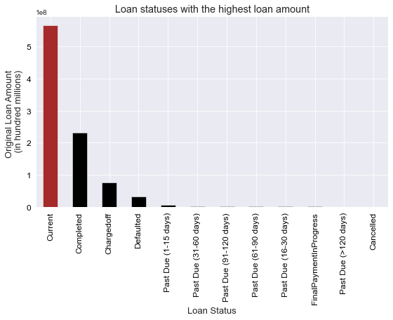

```python
plt.figure(figsize=(9,5))
lon = loan_df.groupby(['LoanStatus']).sum()['LoanOriginalAmount'].sort_values(ascending=False)
lon.plot(kind = 'bar', color = cols)
plt.ylabel('Original Loan Amount \n (in hundred millions)', fontsize=13)
plt.xlabel('Loan Status', fontsize=13)
plt.xticks(fontsize=12, c='k')
plt.yticks(fontsize=12, c='k')
plt.title('Loan statuses with the highest loan amount')
plt.show()
```

#### OBSERVATIONS

- Current listings have the highest sum of original loan amount of over 500 million dollars.
- Defaulted and Charged off listings have a low sum of original loan amounts.

#### QUESTION

What is the relationship between BorrowerAPR and LenderYield

#### VISUALIZATION

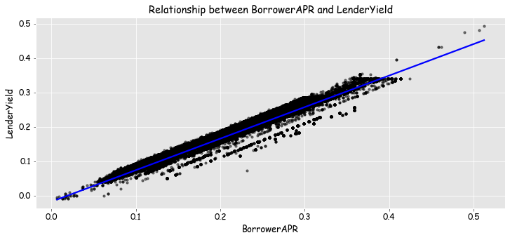

```python
# scatterplot of BorrowerAPR vs Lender's yield
plt.figure(figsize=(12,5))
plt.style.use('ggplot')
sns.regplot(x='BorrowerAPR', y='LenderYield', data=loan_df,
            scatter_kws={"color": "black", "s":10, "alpha":0.5}, line_kws={"color": "blue"})
plt.xticks(fontsize=12, c='k')
plt.yticks(fontsize=12, c='k')
plt.xlabel('BorrowerAPR', fontsize=13, c='k')
plt.ylabel('LenderYield', fontsize=13, c='k')
plt.title('Relationship between BorrowerAPR and LenderYield', c='k')
plt.show()
```

#### OBSERVATIONS

- There is a strong positive relationship between Borrower APR and the Lender Yield.
- The higher the Borrower APR, the higher the Lender Yield, and vice versa

#### QUESTION

What is the distribution of borrower rates for each credit grade?

#### VISUALIZATION

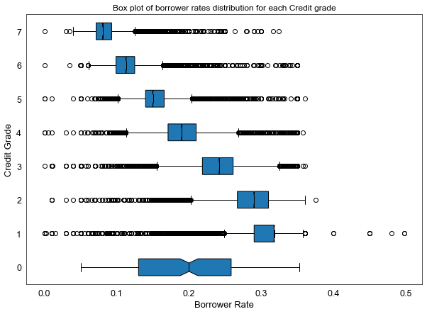

```python
Grade_0 = list(loan_df.query('Credit_Grade_Numeric==0')['BorrowerRate'])
Grade_1 = list(loan_df.query('Credit_Grade_Numeric==1')['BorrowerRate'])
Grade_2 = list(loan_df.query('Credit_Grade_Numeric==2')['BorrowerRate'])
Grade_3 = list(loan_df.query('Credit_Grade_Numeric==3')['BorrowerRate'])
Grade_4 = list(loan_df.query('Credit_Grade_Numeric==4')['BorrowerRate'])
Grade_5 = list(loan_df.query('Credit_Grade_Numeric==5')['BorrowerRate'])
Grade_6 = list(loan_df.query('Credit_Grade_Numeric==6')['BorrowerRate'])
Grade_7 = list(loan_df.query('Credit_Grade_Numeric==7')['BorrowerRate'])

grades_list = [Grade_0, Grade_1, Grade_2, Grade_3, Grade_4, Grade_5, Grade_6, Grade_7]
grades = ['0', '1', '2', '3', '4', '5', '6', '7']

sns.set_style('white')
plt.figure(figsize=(10,7))
ax = plt.boxplot(grades_list, notch=True, patch_artist=True, vert=False, labels=grades)
for median in ax['medians']:
    median.set(color='k')
plt.xticks(fontsize=12.5, c='k')
plt.yticks(fontsize=12.5, c='k')
plt.xlabel('Borrower Rate', fontsize=13, c='k')
plt.ylabel('Credit Grade', fontsize=13, c='k')
plt.title('Box plot of borrower rates distribution for each Credit grade', c='k')
plt.show()
```

```python
# Assessing the summary statistics of the boxplot for each credit grade

print('Statistics for Credit Grade 0: \n', loan_df.query('Credit_Grade_Numeric==0')['BorrowerRate'].describe(), '\n')
print('Statistics for Credit Grade 1: \n', loan_df.query('Credit_Grade_Numeric==1')['BorrowerRate'].describe(), '\n')
print('Statistics for Credit Grade 2: \n', loan_df.query('Credit_Grade_Numeric==2')['BorrowerRate'].describe(), '\n')
print('Statistics for Credit Grade 3: \n', loan_df.query('Credit_Grade_Numeric==3')['BorrowerRate'].describe(), '\n')
print('Statistics for Credit Grade 4: \n', loan_df.query('Credit_Grade_Numeric==4')['BorrowerRate'].describe(), '\n')
print('Statistics for Credit Grade 5: \n', loan_df.query('Credit_Grade_Numeric==5')['BorrowerRate'].describe(), '\n')
print('Statistics for Credit Grade 6: \n', loan_df.query('Credit_Grade_Numeric==6')['BorrowerRate'].describe(), '\n')
print('Statistics for Credit Grade 7: \n', loan_df.query('Credit_Grade_Numeric==7')['BorrowerRate'].describe())
```

```
Statistics for Credit Grade 0:
 count    270.000000
mean       0.193584
std        0.077256
min        0.050000
25%        0.130225
50%        0.200000
75%        0.258250
max        0.353000
Name: BorrowerRate, dtype: float64

Statistics for Credit Grade 1:
 count    10384.000000
mean         0.296474
std          0.050464
min          0.000000
25%          0.290000
50%          0.317700
75%          0.317700
max          0.497500
Name: BorrowerRate, dtype: float64

Statistics for Credit Grade 2:
 count    12949.000000
mean         0.283927
std          0.039537
min          0.010000
25%          0.266900
50%          0.289900
75%          0.309900
max          0.375000
Name: BorrowerRate, dtype: float64

Statistics for Credit Grade 3:
 count    19223.000000
mean         0.237273
std          0.040585
min          0.000000
25%          0.218500
50%          0.241900
```

[output cut: 32 more lines]

```
50%          0.112900
75%          0.124900
max          0.350000
Name: BorrowerRate, dtype: float64

Statistics for Credit Grade 7:
 count    8636.000000
mean        0.086603
std         0.025539
min         0.000000
25%         0.071600
50%         0.080900
75%         0.093000
max         0.323800
Name: BorrowerRate, dtype: float64
```

#### QUESTION

What is the distribution of borrower rates per year?

#### VISUALIZATION

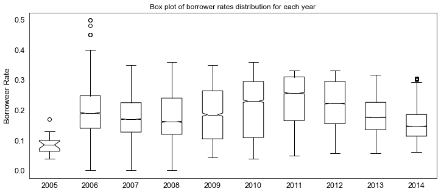

```python
box_data = pd.DataFrame({'Year':list(loan_df['ListingCreationDate'].dt.year), 'Rates':list(loan_df['BorrowerRate'])})
Yr_05 = list(box_data.query('Year==2005')['Rates'])
Yr_06 = list(box_data.query('Year==2006')['Rates'])
Yr_07 = list(box_data.query('Year==2007')['Rates'])
Yr_08 = list(box_data.query('Year==2008')['Rates'])
Yr_09 = list(box_data.query('Year==2009')['Rates'])
Yr_10 = list(box_data.query('Year==2010')['Rates'])
Yr_11 = list(box_data.query('Year==2011')['Rates'])
Yr_12 = list(box_data.query('Year==2012')['Rates'])
Yr_13 = list(box_data.query('Year==2013')['Rates'])
Yr_14 = list(box_data.query('Year==2014')['Rates'])
data = [Yr_05, Yr_06, Yr_07, Yr_08, Yr_09, Yr_10, Yr_11, Yr_12, Yr_13, Yr_14]
yrs = ['2005', '2006', '2007', '2008', '2009', '2010', '2011', '2012', '2013', '2014']

plt.figure(figsize=(12,5))
ax = plt.boxplot(data, notch=True, labels = yrs)
for median in ax['medians']:
    median.set(color='k')
plt.xticks(fontsize=12.5, c='k')
plt.yticks(fontsize=12.5, c='k')
plt.ylabel('Borroweer Rate', fontsize=13, c='k')
plt.title('Box plot of borrower rates distribution for each year', c='k')
plt.show()
```

```python
# Assessing the summary statistics of the boxplot for each year

print('Statistics for 2005: \n', box_data.query('Year==2005')['Rates'].describe(), '\n')
print('Statistics for 2006: \n', box_data.query('Year==2006')['Rates'].describe(), '\n')
print('Statistics for 2007: \n', box_data.query('Year==2007')['Rates'].describe(), '\n')
print('Statistics for 2008: \n', box_data.query('Year==2008')['Rates'].describe(), '\n')
print('Statistics for 2009: \n', box_data.query('Year==2009')['Rates'].describe(), '\n')
print('Statistics for 2010: \n', box_data.query('Year==2010')['Rates'].describe(), '\n')
print('Statistics for 2011: \n', box_data.query('Year==2011')['Rates'].describe(), '\n')
print('Statistics for 2012: \n', box_data.query('Year==2012')['Rates'].describe(), '\n')
print('Statistics for 2013: \n', box_data.query('Year==2013')['Rates'].describe(), '\n')
print('Statistics for 2014: \n', box_data.query('Year==2014')['Rates'].describe())
```

```
Statistics for 2005:
 count    21.000000
mean      0.087688
std       0.032618
min       0.040000
25%       0.063950
50%       0.085000
75%       0.100000
max       0.170000
Name: Rates, dtype: float64

Statistics for 2006:
 count    6153.000000
mean        0.191609
std         0.069116
min         0.000000
25%         0.140000
50%         0.190000
75%         0.247500
max         0.497500
Name: Rates, dtype: float64

Statistics for 2007:
 count    11467.000000
mean         0.176502
std          0.064456
min          0.000000
25%          0.127400
50%          0.170000
75%          0.224800
max          0.350000
Name: Rates, dtype: float64

Statistics for 2008:
 count    11180.000000
mean         0.186601
std          0.085442
min          0.000000
25%          0.120000
50%          0.161500
```

[output cut: 54 more lines]

```
50%          0.176500
75%          0.225900
max          0.316500
Name: Rates, dtype: float64

Statistics for 2014:
 count    10365.000000
mean         0.153497
std          0.054057
min          0.060500
25%          0.113900
50%          0.146500
75%          0.185500
max          0.305900
Name: Rates, dtype: float64
```

### MULTIVARIATE VISUALIZATIONS

#### QUESTION

For the top 3 most common employment status, what are the changes in the yearly sum of borrower rates over time?

#### VISUALIZATION

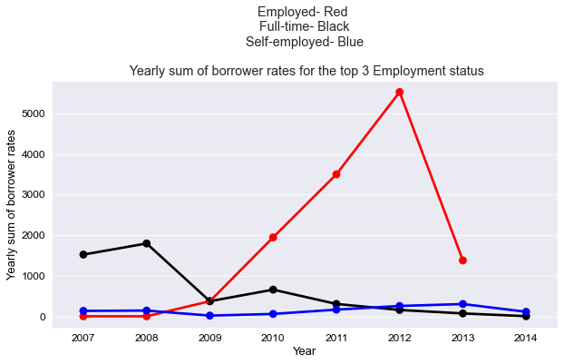

```python
# The top 3 most common employment status are Employed, Full-time, and self-employed

df1 = loan_df.query('EmploymentStatus=="Employed"')['BorrowerRate'].groupby([loan_df['ListingCreationDate'].dt.year]).sum()
df2 = loan_df.query('EmploymentStatus=="Full-time"')['BorrowerRate'].groupby([loan_df['ListingCreationDate'].dt.year]).sum()
df3 = loan_df.query('EmploymentStatus=="Self-employed"')['BorrowerRate'].groupby([loan_df['ListingCreationDate'].dt.year]).sum()

plt.figure(figsize=(10,5))
plt.style.use('ggplot')
sns.pointplot(x = df1.index, y = df1.values, errwidth=0, color='r')
sns.pointplot(x = df2.index, y = df2.values, errwidth=0, color='k')
sns.pointplot(x = df3.index, y = df3.values, errwidth=0, color='b')

plt.xticks(fontsize=12, c='k')
plt.yticks(fontsize=12, c='k')
plt.xlabel('Year', fontsize=13, c='k')
plt.ylabel('Yearly sum of borrower rates', fontsize=13, c='k')
plt.title('Employed- Red \n Full-time- Black \n Self-employed- Blue \n\n Yearly sum of borrower rates for the top 3 Employment status')
plt.show()
```

#### OBSERVATIONS

- The yearly sum of borrower rates for Full-time workers decreased with time
- The yearly sum of borrower rates for self-employed workers went about on a close range (from about 20 to 300)
- The yearly sum of borrower rates for employed workers increased with time until 2013 which saw a great depreciation

#### QUESTION

What are the relationships between BorrowerAPR, BorrowerRate, StatedMonthlyIncome, and AvailableBankCredit?

#### VISUALIZATION

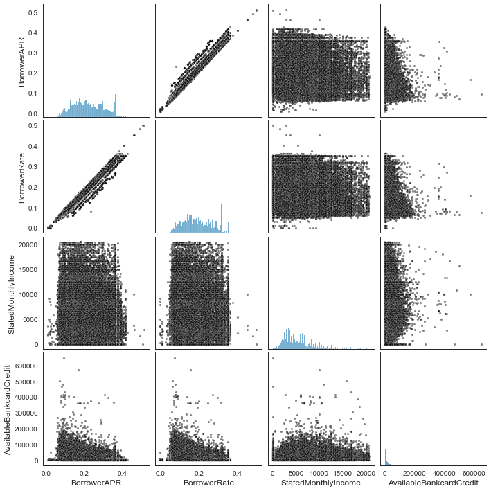

```python
# Multivariate Analysis of variables to see the relationhip between them

df = loan_df[['BorrowerAPR', 'BorrowerRate', 'StatedMonthlyIncome', 'AvailableBankcardCredit']]
sns.pairplot(df, plot_kws={'s':10, 'alpha':0.5, 'color':'black'})
plt.show()
```

#### OBSERVATIONS

- There is only a clear positive relationship between BorrowerAPR and BorrowerRate
- There is a vague negative relationship between AvailableBankCredit and BorrowerRate or BorrowerAPR

### CONCLUSION

*From several data visualizations, through univariate analysis to multivariate analysis, some of the main findings are:*

- *Current and Completed listings constitutes over 70% of the total listings, concludes that Prosper Loan company has a good risk management system.*
- *There is a strong positive relationship between BorrowerRate and LenderYield.*
- *There is a normal distribution of borrower rates in 2005, 2006, 2007, 2008, 2009, and 2013.*
- *The yearly sum of borrower rates for each employment status changes with time.*